# UC00233 — Air Quality Forecasting and Alerts

**Authored by:** John Mulampallil Shaji

**Duration:** 90 mins

**Level:** Intermediate

**Pre-requisite Skills:** Python, pandas, matplotlib, sklearn

## Scenario

As a data analyst working with the City of Melbourne, you have been asked to explore air quality patterns across the city using data from microclimate sensors. Melbourne's sensor network continuously monitors particulate matter (PM2.5 and PM10), temperature, humidity, wind speed and atmospheric pressure across multiple locations.

Your goal is to analyse this data to identify air quality hotspots, understand seasonal patterns, and build a forecasting model to predict PM2.5 levels, thereby enabling vulnerable community members such as those with respiratory conditions to receive timely alerts.

What this use case will teach you

At the end of this use case you will:

- Know how to access the Melbourne Open Data API v2.1 to load real-world sensor data
- Be able to perform exploratory data analysis (EDA) on environmental sensor data
- Understand how to handle missing values using median imputation
- Be able to visualise air quality distributions and trends over time
- Know how to build and evaluate a Random Forest forecasting model for PM2.5 prediction
- Understand how to identify air quality hotspots across Melbourne locations

## Background

Air pollution is a significant public health concern in urban environments. Particulate matter (particularly PM2.5, particles smaller than 2.5 micrometres) can penetrate deep into the lungs and bloodstream, posing serious health risks especially for vulnerable populations.

The City of Melbourne operates a network of microclimate sensors that record air quality and weather measurements every 15 minutes across multiple locations. This dataset is publicly available via the Melbourne Open Data portal and provides a valuable resource for understanding urban air quality patterns.

This use case uses the Microclimate Sensors dataset (dataset ID: microclimate-sensors-data) accessed via the Melbourne Open Data API v2.1.

## Step 1: Load the Dataset

We access the Microclimate Sensors dataset via the Melbourne Open Data API v2.1. The API returns data in JSON format which we convert to a pandas DataFrame.

```python
import pandas as pd
import numpy as np
import matplotlib.pyplot as plt
from sklearn.ensemble import RandomForestRegressor
from sklearn.model_selection import train_test_split
from sklearn.metrics import mean_squared_error, mean_absolute_error, r2_score
from sklearn.preprocessing import MinMaxScaler
import requests

# Load dataset via Melbourne Open Data API v2.1
url = "https://data.melbourne.vic.gov.au/api/explore/v2.1/catalog/datasets/microclimate-sensors-data/exports/csv?lang=en&timezone=Australia%2FMelbourne&use_labels=true&delimiter=%2C"

df = pd.read_csv(url)
print(f"Dataset loaded: {df.shape[0]} rows, {df.shape[1]} columns")
df.head()
```

```
Dataset loaded: 912025 rows, 16 columns
```

|  | Device_id | Time | SensorLocation | LatLong | MinimumWindDirection | AverageWindDirection | MaximumWindDirection | MinimumWindSpeed | AverageWindSpeed | GustWindSpeed | AirTemperature | RelativeHumidity | AtmosphericPressure | PM25 | PM10 | Noise |
| --- | --- | --- | --- | --- | --- | --- | --- | --- | --- | --- | --- | --- | --- | --- | --- | --- |
| 0 | ICTMicroclimate-03 | 2023-05-18T16:09:52+10:00 | CH1 rooftop | -37.8140348, 144.96728 | 179.0 | 200.0 | 211.0 | 1.3 | 1.5 | 2.8 | 12.4 | 68.2 | 1016.7 | 1.0 | 3.0 | 87.7 |
| 1 | ICTMicroclimate-03 | 2023-05-18T15:39:49+10:00 | CH1 rooftop | -37.8140348, 144.96728 | 124.0 | 172.0 | 179.0 | 0.9 | 1.4 | 3.9 | 12.6 | 66.5 | 1016.6 | 1.0 | 3.0 | 76.7 |
| 2 | ICTMicroclimate-03 | 2023-05-18T15:24:47+10:00 | CH1 rooftop | -37.8140348, 144.96728 | 153.0 | 191.0 | 225.0 | 1.2 | 2.2 | 3.4 | 12.9 | 63.1 | 1016.7 | 1.0 | 3.0 | 77.0 |
| 3 | ICTMicroclimate-03 | 2023-05-18T15:09:44+10:00 | CH1 rooftop | -37.8140348, 144.96728 | 215.0 | 193.0 | 215.0 | 2.0 | 1.7 | 2.0 | 12.9 | 63.2 | 1016.6 | 4.0 | 6.0 | 75.6 |
| 4 | ICTMicroclimate-03 | 2023-05-18T14:39:41+10:00 | CH1 rooftop | -37.8140348, 144.96728 | 149.0 | 192.0 | 269.0 | 0.3 | 1.2 | 1.8 | 12.8 | 67.9 | 1017.0 | 2.0 | 4.0 | 71.4 |

```python
# Dataset scope
print(f"Time coverage: {df['Time'].min()} to {df['Time'].max()}")
print(f"Unique sensor locations: {df['SensorLocation'].nunique()}")
print(f"Total records: {len(df):,}")
```

```
Time coverage: 2022-05-31T10:11:28+10:00 to 2026-05-24T16:04:26+10:00
Unique sensor locations: 11
Total records: 912,025
```

## Step 2: Exploratory Data Analysis

We begin by understanding the structure of the dataset including feature names, data types and missing values.

```python
# Dataset overview
print("Column names and data types:")
df.info()
```

```
Column names and data types:
<class 'pandas.DataFrame'>
RangeIndex: 912025 entries, 0 to 912024
Data columns (total 16 columns):
 #   Column                Non-Null Count   Dtype
---  ------                --------------   -----
 0   Device_id             912025 non-null  str
 1   Time                  912025 non-null  str
 2   SensorLocation        912025 non-null  str
 3   LatLong               912025 non-null  str
 4   MinimumWindDirection  776318 non-null  float64
 5   AverageWindDirection  896311 non-null  float64
 6   MaximumWindDirection  776308 non-null  float64
 7   MinimumWindSpeed      776308 non-null  float64
 8   AverageWindSpeed      896309 non-null  float64
 9   GustWindSpeed         776308 non-null  float64
 10  AirTemperature        896309 non-null  float64
 11  RelativeHumidity      896309 non-null  float64
 12  AtmosphericPressure   896309 non-null  float64
 13  PM25                  837472 non-null  float64
 14  PM10                  837472 non-null  float64
 15  Noise                 837472 non-null  float64
dtypes: float64(12), str(4)
memory usage: 202.3 MB
```

```python
# Missing values per feature
print("Missing values per feature:")
df.isnull().sum()
```

```
Missing values per feature:
```

```
Device_id                    0
Time                         0
SensorLocation               0
LatLong                      0
MinimumWindDirection    135707
AverageWindDirection     15714
MaximumWindDirection    135717
MinimumWindSpeed        135717
AverageWindSpeed         15716
GustWindSpeed           135717
AirTemperature           15716
RelativeHumidity         15716
AtmosphericPressure      15716
PM25                     74553
PM10                     74553
Noise                    74553
dtype: int64
```

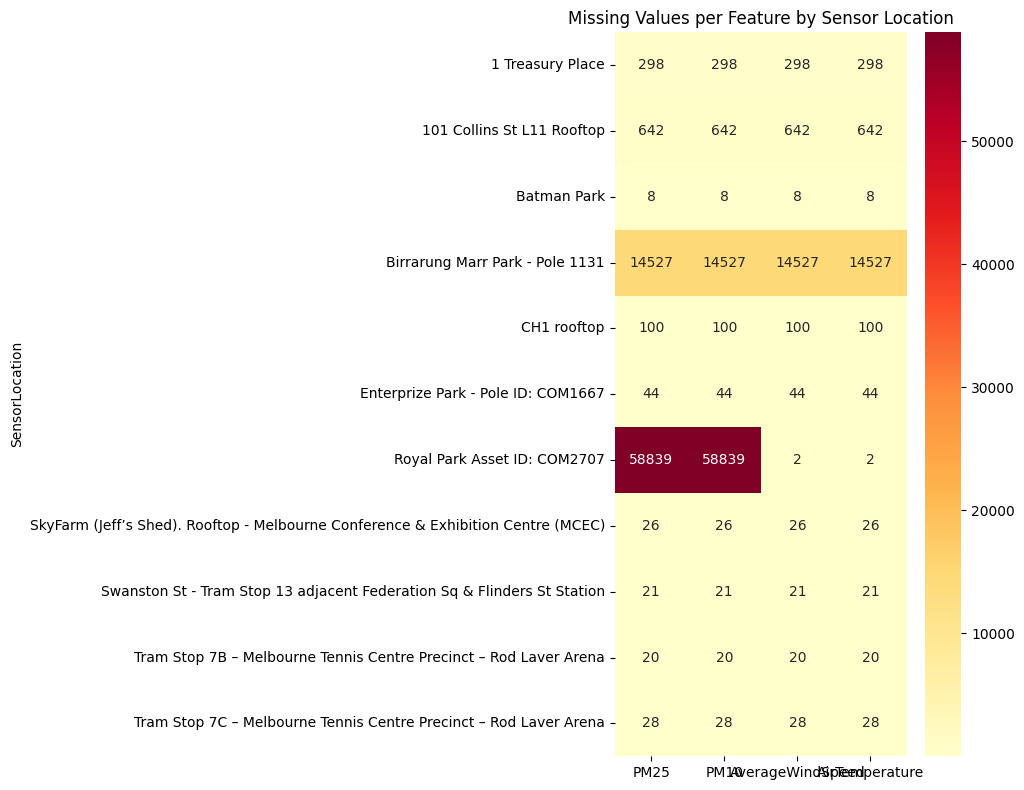

```python
import seaborn as sns

# Missing data heatmap by sensor
missing_by_sensor = df.groupby('SensorLocation')[['PM25', 'PM10', 'AverageWindSpeed', 'AirTemperature']].apply(lambda x: x.isnull().sum())

plt.figure(figsize=(10, 8))
sns.heatmap(missing_by_sensor, cmap='YlOrRd', annot=True, fmt='d')
plt.title('Missing Values per Feature by Sensor Location')
plt.tight_layout()
plt.show()
```

```python
# Statistical summary
df.describe()
```

|  | MinimumWindDirection | AverageWindDirection | MaximumWindDirection | MinimumWindSpeed | AverageWindSpeed | GustWindSpeed | AirTemperature | RelativeHumidity | AtmosphericPressure | PM25 | PM10 | Noise |
| --- | --- | --- | --- | --- | --- | --- | --- | --- | --- | --- | --- | --- |
| count | 776318.000000 | 896311.000000 | 776308.000000 | 776308.000000 | 896309.000000 | 776308.000000 | 896309.000000 | 896309.000000 | 896309.000000 | 837472.000000 | 837472.000000 | 837472.000000 |
| mean | 23.892728 | 166.191729 | 295.511978 | 0.230432 | 1.001122 | 3.161893 | 16.650099 | 68.249442 | 1014.096571 | 6.754768 | 9.043335 | 66.414143 |
| std | 61.622665 | 125.834288 | 97.736287 | 0.571404 | 0.939109 | 2.503748 | 5.558136 | 17.594473 | 9.836597 | 29.894147 | 30.337709 | 11.163459 |
| min | 0.000000 | 0.000000 | 0.000000 | 0.000000 | 0.000000 | 0.000000 | -0.800000 | 2.500000 | 894.700000 | 0.000000 | 0.000000 | 0.000000 |
| 25% | 0.000000 | 41.000000 | 251.000000 | 0.000000 | 0.300000 | 1.300000 | 12.800000 | 56.700000 | 1008.600000 | 1.000000 | 3.000000 | 58.500000 |
| 50% | 0.000000 | 160.000000 | 351.000000 | 0.000000 | 0.700000 | 2.500000 | 16.100000 | 69.600000 | 1014.300000 | 3.000000 | 5.000000 | 68.100000 |
| 75% | 0.000000 | 299.000000 | 357.000000 | 0.100000 | 1.400000 | 4.400000 | 19.700000 | 81.100000 | 1020.100000 | 7.000000 | 9.000000 | 71.700000 |
| max | 359.000000 | 359.000000 | 360.000000 | 11.600000 | 11.200000 | 52.500000 | 45.400002 | 99.800003 | 1042.900000 | 3414.000000 | 3414.000000 | 131.100000 |

## Step 3: Data Cleaning

```python
# Median imputation for numeric columns
for column in df.columns:
    if df[column].isnull().sum() > 0:
        if df[column].dtype in ['int64', 'float64']:
            median_val = df[column].median()
            df[column] = df[column].fillna(median_val)
            print(f"{column}: filled with median = {median_val}")
```

```
MinimumWindDirection: filled with median = 0.0
AverageWindDirection: filled with median = 160.0
MaximumWindDirection: filled with median = 351.0
MinimumWindSpeed: filled with median = 0.0
AverageWindSpeed: filled with median = 0.7
GustWindSpeed: filled with median = 2.5
AirTemperature: filled with median = 16.1
RelativeHumidity: filled with median = 69.6
AtmosphericPressure: filled with median = 1014.3
PM25: filled with median = 3.0
PM10: filled with median = 5.0
Noise: filled with median = 68.1
```

## Step 4: Air Quality Analysis

We examine the distributions of PM2.5 and PM10 (the primary air quality indicators) and analyse their correlation.

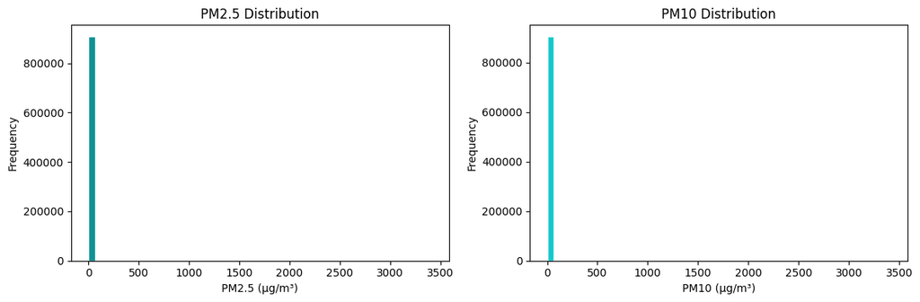

```
Correlation between PM2.5 and PM10: 0.9969
```

```python
fig, axes = plt.subplots(1, 2, figsize=(12, 4))

axes[0].hist(df['PM25'], bins=50, color='#0f9295', edgecolor='white')
axes[0].set_title('PM2.5 Distribution')
axes[0].set_xlabel('PM2.5 (µg/m³)')
axes[0].set_ylabel('Frequency')

axes[1].hist(df['PM10'], bins=50, color='#14c9cb', edgecolor='white')
axes[1].set_title('PM10 Distribution')
axes[1].set_xlabel('PM10 (µg/m³)')
axes[1].set_ylabel('Frequency')

plt.tight_layout()
plt.show()

correlation = df['PM25'].corr(df['PM10'])
print(f"Correlation between PM2.5 and PM10: {correlation:.4f}")
```

Both PM2.5 and PM10 show heavily right-skewed distributions with most values clustered at low levels and a small number of extreme outliers. The correlation coefficient of 0.9969 indicates a very strong positive correlation between them, suggesting that when PM2.5 levels rise, PM10 levels rise proportionally. This makes sense as both measure particulate matter from similar pollution sources such as vehicle emissions and industrial activity.

## Step 5: Air Quality Hotspots by Location

Which sensor locations record the highest average PM2.5 levels? Identifying hotspots helps target alerts to vulnerable communities in affected areas.

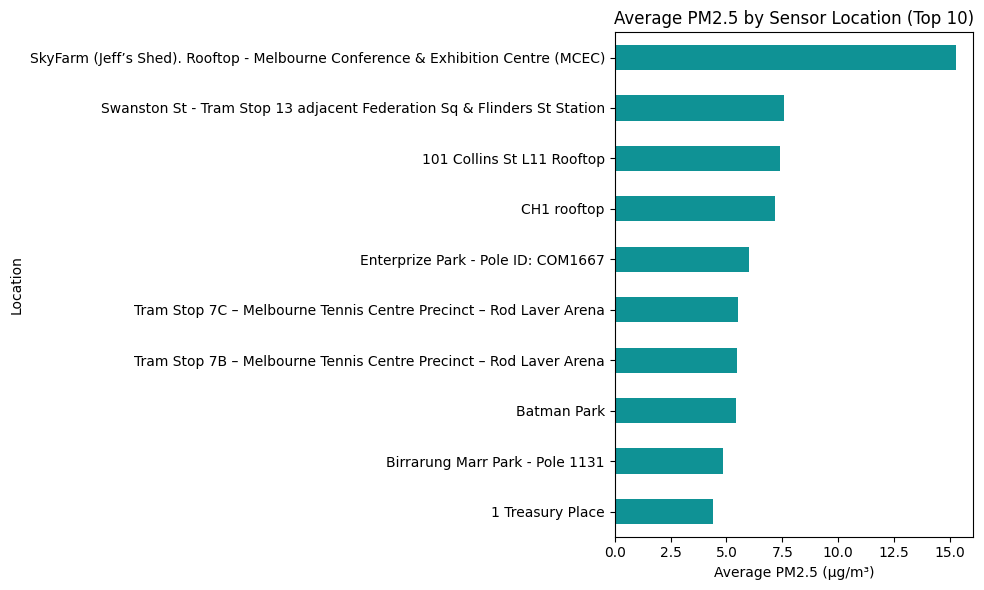

```
SensorLocation
SkyFarm (Jeff’s Shed). Rooftop - Melbourne Conference & Exhibition Centre (MCEC)    15.283878
Swanston St - Tram Stop 13 adjacent Federation Sq & Flinders St Station              7.565043
101 Collins St L11 Rooftop                                                           7.393694
CH1 rooftop                                                                          7.178670
Enterprize Park - Pole ID: COM1667                                                   6.008226
Tram Stop 7C – Melbourne Tennis Centre Precinct – Rod Laver Arena                    5.519077
Tram Stop 7B – Melbourne Tennis Centre Precinct – Rod Laver Arena                    5.451804
Batman Park                                                                          5.422232
Birrarung Marr Park - Pole 1131                                                      4.867061
1 Treasury Place                                                                     4.406700
Name: PM25, dtype: float64
```

```python
pm25_by_location = df.groupby('SensorLocation')['PM25'].mean().sort_values(ascending=False).head(10)

pm25_by_location.plot(kind='barh', figsize=(10, 6), color='#0f9295')
plt.title('Average PM2.5 by Sensor Location (Top 10)')
plt.xlabel('Average PM2.5 (µg/m³)')
plt.ylabel('Location')
plt.gca().invert_yaxis()
plt.tight_layout()
plt.show()

print(pm25_by_location)
```

## Step 6: PM2.5 Trends Over Time

We examine monthly PM2.5 trends to identify seasonal patterns relevant to forecasting.

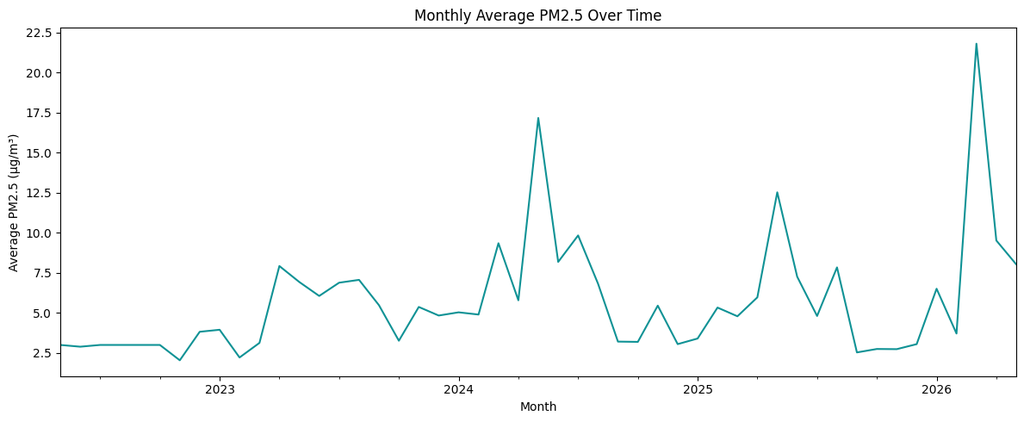

```python
df['Time'] = pd.to_datetime(df['Time'], utc=True)

monthly_pm25 = df.groupby(df['Time'].dt.tz_localize(None).dt.to_period('M'))['PM25'].mean()

monthly_pm25.plot(figsize=(12, 5), color='#0f9295')
plt.title('Monthly Average PM2.5 Over Time')
plt.xlabel('Month')
plt.ylabel('Average PM2.5 (µg/m³)')
plt.tight_layout()
plt.show()
```

## Step 7: Feature Engineering

We prepare features for the forecasting model by extracting time-based features and encoding location information.

```python
# Extract time-based features
df['hour'] = df['Time'].dt.hour
df['month'] = df['Time'].dt.month
df['dayofweek'] = df['Time'].dt.dayofweek

# Split LatLong into Latitude and Longitude
df[['Latitude', 'Longitude']] = df['LatLong'].str.split(',', expand=True)
df['Latitude'] = df['Latitude'].astype(float)
df['Longitude'] = df['Longitude'].astype(float)

# Scale Latitude and Longitude
scaler = MinMaxScaler()
df[['Latitude', 'Longitude']] = scaler.fit_transform(df[['Latitude', 'Longitude']])

print("Features engineered successfully")
df[['hour', 'month', 'dayofweek', 'Latitude', 'Longitude']].head()
```

[output not shown]

## Step 8: Random Forest Forecasting Model

We build a Random Forest model to forecast PM2.5 levels based on weather features and time-based variables. Random Forest is well suited to this task as it handles non-linear relationships and is robust to outliers, both of which are characteristics of this dataset.

**Forecasting Setup:**

- **Target:** PM2.5 at current timestep
- **Input features:** AverageWindSpeed, AirTemperature, RelativeHumidity, AtmosphericPressure, hour, month, dayofweek, Latitude, Longitude

```python
# Select features and target
features = ['AverageWindSpeed', 'AirTemperature', 'RelativeHumidity',
            'AtmosphericPressure', 'hour', 'month', 'dayofweek',
            'Latitude', 'Longitude']

target = 'PM25'

# Drop rows with missing values in selected features
model_df = df[features + [target]].dropna()

X = model_df[features]
y = model_df[target]

# Train/test split
X_train, X_test, y_train, y_test = train_test_split(X, y, test_size=0.2, random_state=42)

# Train Random Forest model
rf_model = RandomForestRegressor(n_estimators=100, random_state=42)
rf_model.fit(X_train, y_train)

# Evaluate
y_pred = rf_model.predict(X_test)
rmse = np.sqrt(mean_squared_error(y_test, y_pred))
mae = mean_absolute_error(y_test, y_pred)
r2 = r2_score(y_test, y_pred)

print(f"RMSE: {rmse:.4f}")
print(f"MAE: {mae:.4f}")
print(f"R² Score: {r2:.4f}")
```

[output not shown]

```python
# Feature importance
importance = pd.Series(rf_model.feature_importances_, index=features).sort_values(ascending=False)

importance.plot(kind='bar', figsize=(10, 5), color='#0f9295')
plt.title('Feature Importance for PM2.5 Forecasting')
plt.xlabel('Feature')
plt.ylabel('Importance Score')
plt.xticks(rotation=45)
plt.tight_layout()
plt.show()
```

[output not shown]

```python
plt.figure(figsize=(10, 5))
plt.plot(y_test.values[:100], label='Actual PM2.5', color='#0f9295')
plt.plot(y_pred[:100], label='Predicted PM2.5', color='#056b8a', linestyle='--')
plt.title('Actual vs Predicted PM2.5 (First 100 Test Samples)')
plt.xlabel('Sample')
plt.ylabel('PM2.5 (µg/m³)')
plt.legend()
plt.tight_layout()
plt.show()
```

[output not shown]

## Step 9: Model Comparison

To evaluate whether Random Forest is the best approach, we compare it against a Linear Regression baseline. This helps justify our model selection and understand the complexity of the relationship between weather features and PM2.5 levels.

```python
from sklearn.linear_model import LinearRegression

# Linear Regression baseline
lr_model = LinearRegression()
lr_model.fit(X_train, y_train)
y_pred_lr = lr_model.predict(X_test)

rmse_lr = np.sqrt(mean_squared_error(y_test, y_pred_lr))
mae_lr = mean_absolute_error(y_test, y_pred_lr)
r2_lr = r2_score(y_test, y_pred_lr)

print("Model Comparison:")
print(f"\nLinear Regression:")
print(f"  RMSE: {rmse_lr:.4f}")
print(f"  MAE: {mae_lr:.4f}")
print(f"  R² Score: {r2_lr:.4f}")

print(f"\nRandom Forest:")
print(f"  RMSE: {rmse:.4f}")
print(f"  MAE: {mae:.4f}")
print(f"  R² Score: {r2:.4f}")
```

[output not shown]

```python
models = ['Linear Regression', 'Random Forest']
rmse_scores = [rmse_lr, rmse]
mae_scores = [mae_lr, mae]
r2_scores = [r2_lr, r2]

x = np.arange(len(models))
width = 0.25

fig, axes = plt.subplots(1, 3, figsize=(14, 5))

axes[0].bar(x, rmse_scores, width, color=['#14c9cb', '#0f9295'])
axes[0].set_title('RMSE Comparison (lower is better)')
axes[0].set_xticks(x)
axes[0].set_xticklabels(models)
axes[0].set_ylabel('RMSE')

axes[1].bar(x, mae_scores, width, color=['#14c9cb', '#0f9295'])
axes[1].set_title('MAE Comparison (lower is better)')
axes[1].set_xticks(x)
axes[1].set_xticklabels(models)
axes[1].set_ylabel('MAE')

axes[2].bar(x, r2_scores, width, color=['#14c9cb', '#0f9295'])
axes[2].set_title('R² Comparison (higher is better)')
axes[2].set_xticks(x)
axes[2].set_xticklabels(models)
axes[2].set_ylabel('R² Score')

plt.tight_layout()
plt.show()
```

[output not shown]

## Future Directions and Recommendations

**1. Deep Learning with LSTM** PM2.5 levels are inherently time-series data, air quality at any given moment is influenced by recent past readings. A Long Short-Term Memory (LSTM) neural network is specifically designed to capture these temporal dependencies, making it a natural next step for improving forecast accuracy. Unlike Random Forest which treats each observation independently, LSTM can learn patterns across time sequences.

**2. Incorporating Additional Pollutants** The current model uses weather features to predict PM2.5. Incorporating additional pollutants such as NO₂ and CO concentrations as input features could improve accuracy, as vehicle emissions contribute to both traffic congestion and particulate matter levels. Research suggests air quality and traffic flow are correlated with dense slow-moving traffic increases vehicle emissions which in turn elevates PM2.5 and NO₂ levels.

**3. Spatial Modelling** Currently each sensor location is treated independently. A spatial model that accounts for the geographic relationships between sensor locations could improve predictions as air quality at one location is likely influenced by nearby sensors.

**4. Real-Time Alert System** The forecasting model could be integrated into a real-time alert system that notifies vulnerable community members (elderly, asthmatic) when PM2.5 levels are predicted to exceed safe thresholds, directly addressing the project's community impact goal.

## Summary and Conclusions

**Key findings:**

- PM2.5 and PM10 show heavily right-skewed distributions with extreme outliers
- Strong correlation (0.9969) between PM2.5 and PM10 suggesting they share common pollution sources
- Certain locations consistently record higher PM2.5 levels, identifying potential hotspots
- The Random Forest model successfully forecasts PM2.5 levels using weather and time-based features

**References:**

- City of Melbourne Open Data Portal: https://data.melbourne.vic.gov.au
- Microclimate Sensors Dataset: https://data.melbourne.vic.gov.au/explore/dataset/microclimate-sensors-data
- Scikit-learn Documentation: https://scikit-learn.org
- R. Abduljabbar, H. Dia, and S. Liyanage, "Machine learning traffic flow prediction models for smart and sustainable traffic management," *Infrastructures*, vol. 10, no. 7, Art. 155, 2025, doi: 10.3390/infrastructures10070155.